# Shark Attack Research

## **5.4 Correlation among the attributes**

Correlation between the attributes has been calculated and it was observed that DailyAverageTemperature and DailyAverageDewPotTemp are strongly correlated so it is likely that one of them may be left out during modeling.*Please refer to EDA section*

## **5.5 Normalization**

Since DailyAverageTemperature, DailyAverageDewPotTemp, DailyAverageWdSpeed, and DailyPrecipitation columns were on different scale making it difficult to compare them. Therefore, normalization has been carried out in order to bring them into the same scale.

```r
means = apply(complete_data,2,mean)
sds = apply(complete_data,2,sd)
shark.data.normalized = scale(complete_data,center=means,scale=sds)
shark.data.normalized <- as.data.frame(shark.data.normalized)

shark.data$DailyPrecipitation_normalized <- shark.data.normalized$DailyPrecipitation
shark.data$DailyAverageDewPotTemp_normalized <- shark.data.normalized$DailyAverageDewPotTemp
shark.data$DailyAverageWdSpeed_normalized <- shark.data.normalized$DailyAverageWdSpeed
shark.data$DailyAverageTemperature_normalized <- shark.data.normalized$DailyAverageTemperature

head(shark.data)
```

```
##   Sno      Date Wd.Direction     moonphase Year           Area
## 1   1 7/22/2009          ESE           New 2009 North Carolina
## 2   2 9/12/2009          SSW Third quarter 2009 North Carolina
## 3   3 6/25/2010           SW          Full 2010 North Carolina
## 4   4 6/25/2010           SW          Full 2010 South Carolina
## 5   5 7/17/2010           SW First quarter 2010 North Carolina
## 6   6 7/19/2010           SW First quarter 2010 South Carolina
##                                 Location  Time Attack time.o.attack
## 1         Holden Beach, Brunswick County 15h00    Yes           Day
## 2              Corolla, Currituck County 21h00    Yes          Dusk
## 3          Topsail Island, Pender County 13h00    Yes           Day
## 4          Fripp Island, Beaufort County  <NA>    Yes          Dawn
## 5 Wrightsville Beach, New Hanover County 13h30    Yes           Day
## 6             Myrtle Beach, Horry County 10h35    Yes           Day
##   DailyPrecipitation DailyAverageWdSpeed DailyAverageDewPotTemp
```

[output cut: 48 more lines]

## **5.6 Principal Component Analysis**

As correlation showed Dew point temperature and average daily temperature are strongly related, we applied PCA which also showed the same results. Using domain knowledge we know, temperature will mostly be high during this durationin North and South Carolina. Therefore we can remove that column.

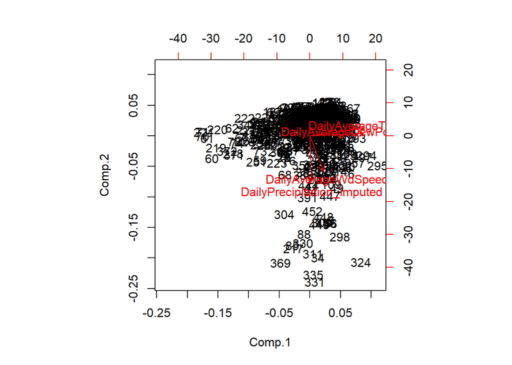

```r
d <- shark.data[,c(14,12,16,17)]
pc <- princomp(d, cor= TRUE,score= TRUE)
biplot(pc)
```

## **5.7 Calculation of Proportion after undersampling**

The number of records with Attack equal to Yes were 77 in total. This was definitely less than the total number of days taken for the years between the months of May to September. Hence when the GSAF file was combined with the file con-taining all dates it led to a data imbalance problem. In order to solve the problem, a stratified sampling of Attack=No subset was prepared so that 1/3 of records remain with adequate representation for each class. To evaluate the efficiency of the solution applied to the data imbalance problem, undersampling of the records with attack=“No” was done and the proportions of wind speed, wind direction and moonphase was compared with the original dataset.

Reading the file which has undersampled data

Presenting the before and after proportions in a table

```r
#converting all the variables into matrix

proportional_table <- matrix(c( new_moon_prop_original, new_moon_prop_undersample, full_moon_prop_original, full_moon_prop_undersample,
                                firstQ_moon_prop_original, firstQ_moon_prop_undersample, WaningG_moon_prop_original, WaningG_moon_prop_undersample,
                                SW_Wdirection_prop_original, SW_Wdirection_prop_undersample,  SSW_Wdirection_prop_original, SSW_Wdirection_prop_undersample,
                                WSW_Wdirection_prop_original, WSW_Wdirection_prop_undersample, E_Wdirection_prop_original, E_Wdirection_prop_undersample,
                                High_Wspeed_prop_original, High_Wspeed_prop_undersample, Medium_Wspeed_prop_original, Medium_Wspeed_prop_undersample,
                                Low_Wspeed_prop_original, Low_Wspeed_prop_undersample ),ncol=2,byrow=TRUE)
#adding column names to the proportional matrix
colnames(proportional_table) <- c("Original Proportion","Undersample Proportion")
#adding row names to the proportional matrix
rownames(proportional_table) <- c("New Moon","Full Moon","First Quarter","Waning Gibbous", "Wind Direction - SW", "Wind Direction - SSW", "Wind Direction - WSW ","Wind Direction - East", "Wind Direction - High", "Wind Direction - Medium", "Wind Direction - Low")
#Converting the matrix into table
proportional_table <- as.table(proportional_table)
```

displaying the proportional table

```r
proportional_table
```

```
##                         Original Proportion Undersample Proportion
## New Moon                         0.15859031             0.14400000
## Full Moon                        0.13656388             0.12800000
## First Quarter                    0.13656388             0.14000000
## Waning Gibbous                   0.12334802             0.12800000
## Wind Direction - SW              0.15859031             0.16000000
## Wind Direction - SSW             0.08810573             0.06000000
## Wind Direction - WSW             0.20925110             0.22800000
## Wind Direction - East            0.04845815             0.03600000
## Wind Direction - High            0.51762115             0.52400000
## Wind Direction - Medium          0.14757709             0.08000000
## Wind Direction - Low             0.33480176             0.39600000
```

# **6. Data Modelling Plan**

Cross-Validation technique will be applied on the dataset to divide it among training and test dataset. The target variable for Shark Attack is a categorical value. Therefore, different classification algorithms like decision trees and k nearest neighbour will be applied on for training the model. Results for both the models will then be evaluated and the best model will be selected for prediction. Depending on the detail of this analysis, clustering and association rules can be touched along with classification methods.

## **6.1 Data Partitioning**

```r
shark.data.modelling$Wd.Direction <- factor(shark.data.modelling$Wd.Direction)
shark.data.modelling$Attack <- factor(shark.data.modelling$Attack)
shark.data.modelling$moonphase <- factor(shark.data.modelling$moonphase)
```

```r
library(caret)
train.rows <- createDataPartition(y= shark.data.modelling$Attack, p=0.75, list = FALSE)
train.data <- shark.data.modelling[train.rows,]
table(train.data$Attack)
```

```
##
##  No Yes
## 188  58
```

```r
test.data <- shark.data.modelling[-train.rows,]
table(test.data$Attack)
```

```
##
##  No Yes
##  62  19
```

```r
str(shark.data.modelling)
```

```
## 'data.frame':    327 obs. of  25 variables:
##  $ Sno                               : int  1 2 3 4 5 6 7 8 9 10 ...
##  $ Date                              : chr  "7/22/2009" "9/12/2009" "6/25/2010" "6/25/2010" ...
##  $ Wd.Direction                      : Factor w/ 16 levels "E","ENE","ESE",..: 3 12 13 13 13 13 13 1 12 11 ...
##  $ moonphase                         : Factor w/ 9 levels "First quarter",..: 4 5 2 2 1 1 2 4 7 2 ...
##  $ Year                              : int  2009 2009 2010 2010 2010 2010 2010 2010 2011 2011 ...
##  $ Area                              : chr  "North Carolina" "North Carolina" "North Carolina" "South Carolina" ...
##  $ Location                          : chr  "Holden Beach, Brunswick County" "Corolla, Currituck County" "Topsail Island, Pender County" "Fripp Island, Beaufort County" ...
##  $ Time                              : chr  "15h00" "21h00" "13h00" NA ...
##  $ Attack                            : Factor w/ 2 levels "No","Yes": 2 2 2 2 2 2 2 2 2 2 ...
##  $ time.o.attack                     : chr  "Day" "Dusk" "Day" "Dawn" ...
##  $ DailyPrecipitation                : num  0.31 0 0 0 1 0 0 0 0 0 ...
##  $ DailyAverageWdSpeed               : num  6.8 5.2 8.4 11.4 15.2 14.8 13 5.8 9.2 6 ...
##  $ DailyAverageDewPotTemp            : num  71 66 76 77 77 76 79 76 NA NA ...
##  $ DailyAverageTemperature           : num  79 70 80 86 76 84 86 81 82 83 ...
##  $ County                            : chr  "Brunswick" "Currituck" "Pender" "Beaufort" ...
##  $ DailyAverageDewPotTemp_imputed    : num  71 66 76 77 77 76 79 76 76.8 79.9 ...
##  $ DailyPrecipitation_imputed        : num  0.31 0 0 0 1 0 0 0 0 0 ...
##  $ binned.DailyAverageTemperature    : chr  "Low" "Medium" "Low" "Low" ...
##  $ binned.DailyAverageDewPotTemp     : chr  "High" "High" "Low" "Low" ...
##  $ binned.DailyAverageWdSpeed        : chr  "High" "High" "Medium" "Medium" ...
##  $ binned.DailyPrecipitation         : chr  "High" "High" "High" "High" ...
##  $ DailyPrecipitation_normalized     : num  0.19 -0.376 -0.376 -0.376 1.45 ...
##  $ DailyAverageDewPotTemp_normalized : num  -0.118 -0.924 0.688 0.849 0.849 ...
##  $ DailyAverageWdSpeed_normalized    : num  0.704 0.23 1.178 2.068 3.194 ...
##  $ DailyAverageTemperature_normalized: num  0.388 -1.398 0.586 1.777 -0.207 ...
```

# **7. Data Modelling**

For our modeling we tested using cross validation, but as it turns out the results varied only by a few percent for each split. This may be due in part to the fact that we chose to only use three splits, because our undersampled dataset is not that large and splitting it too much may remove some of the classes. Consequently, we only use a simple train/test split for our modeling here.

We did find that the model results varied a lot, around 10%, based on the random undersampling of the main dataset. Even though we checked that the undersampled dataset was representative of the main one it still produced widely variable results. To combat this further research may want to investigate alternative methods of balancing a dataset such as oversampling or creating synthetic samples.

## **7.1 Random Forest and Decision Tree**

We are going to use a random forest for our predictions as it is a more accurate ensemble emthod for decision trees, but first we will look at the structure of one decision tree to get an idea of how the data is being split. We train a decision tree using moonphase, wind speed, and wind direction to predict shark attacks. We chose these values based on domain knowledge as well as the fact that our data is taken from the summer months so temperature and precipitation do no vary enough to contribute to our model. We also tested binned and transformed versions of these variables, but none of those variations increased the accuracy.

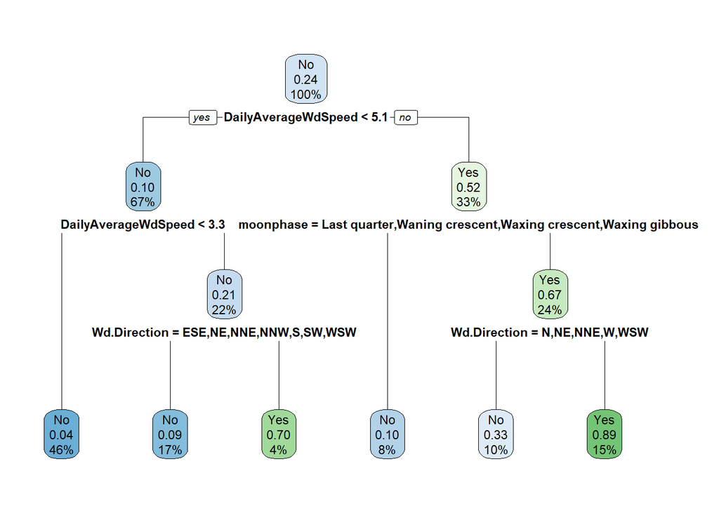

```r
tree <- rpart(Attack ~ Wd.Direction + moonphase + DailyAverageWdSpeed, data = train.data, method = "class")
rpart.plot(tree)
```

From the tree it looks like wind speed is the most important characteristic.

Now we will use those same features to train a random forest. We then examine the model and also check which of the predictors is most important to the classification.

```r
rf_classifier = randomForest(Attack ~ Wd.Direction + moonphase + DailyAverageWdSpeed, data=train.data, ntree=100, mtry=2, importance=TRUE)
rf_classifier
```

```
##
## Call:
##  randomForest(formula = Attack ~ Wd.Direction + moonphase + DailyAverageWdSpeed,      data = train.data, ntree = 100, mtry = 2, importance = TRUE)
##                Type of random forest: classification
##                      Number of trees: 100
## No. of variables tried at each split: 2
##
##         OOB estimate of  error rate: 16.26%
## Confusion matrix:
##      No Yes class.error
## No  171  17  0.09042553
## Yes  23  35  0.39655172
```

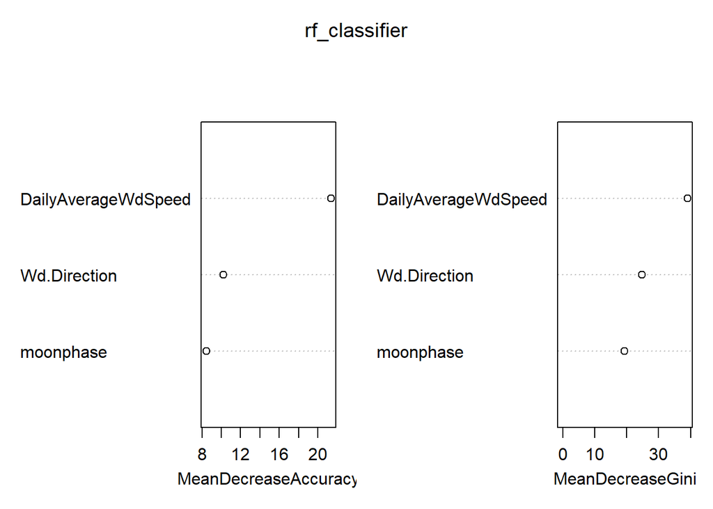

```r
varImpPlot(rf_classifier)
```

Then we test our forest by classifying new data. To check our accuracy we look at a confusion matrix, gain curve plot, ROC plot, and AUC.

```r
test.data$forest.pred <- predict(rf_classifier, test.data)
confusionMatrix(test.data$Attack, test.data$forest.pred, positive = "Yes")
```

```
## Confusion Matrix and Statistics
##
##           Reference
## Prediction No Yes
##        No  58   4
##        Yes  5  14
##
##                Accuracy : 0.8889
##                  95% CI : (0.7995, 0.9479)
##     No Information Rate : 0.7778
##     P-Value [Acc > NIR] : 0.007962
##
##                   Kappa : 0.6848
##  Mcnemar's Test P-Value : 1.000000
##
##             Sensitivity : 0.7778
##             Specificity : 0.9206
##          Pos Pred Value : 0.7368
##          Neg Pred Value : 0.9355
##              Prevalence : 0.2222
##          Detection Rate : 0.1728
##    Detection Prevalence : 0.2346
##       Balanced Accuracy : 0.8492
##
##        'Positive' Class : Yes
##
```

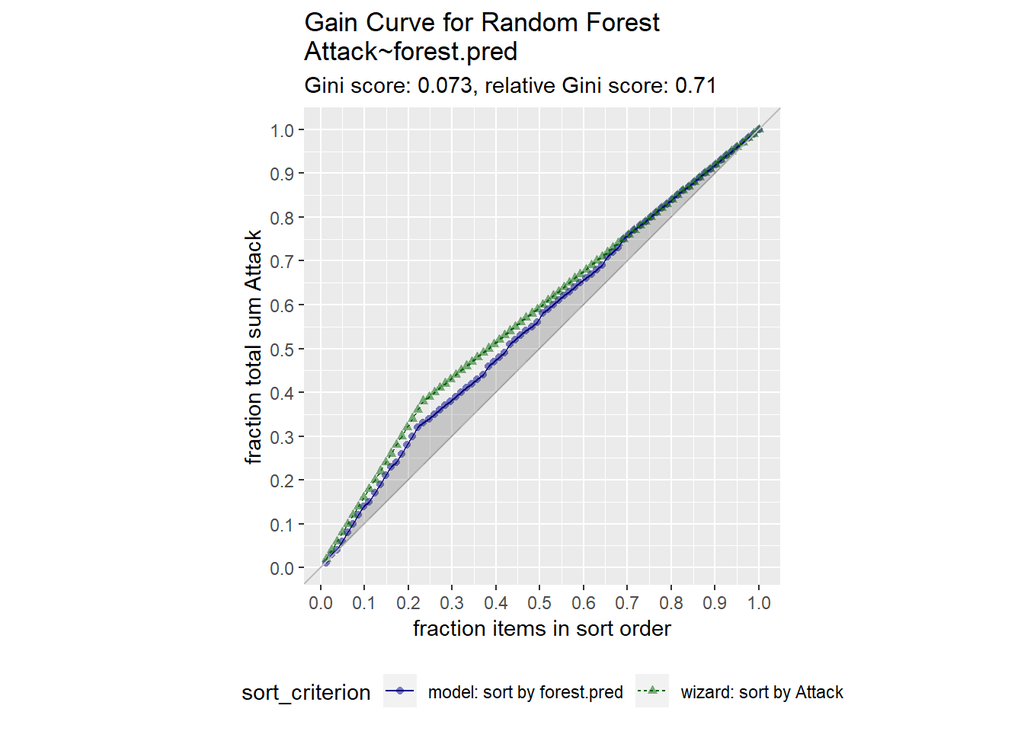

```r
GainCurvePlot(test.data, "forest.pred", "Attack", "Gain Curve for Random Forest")
```

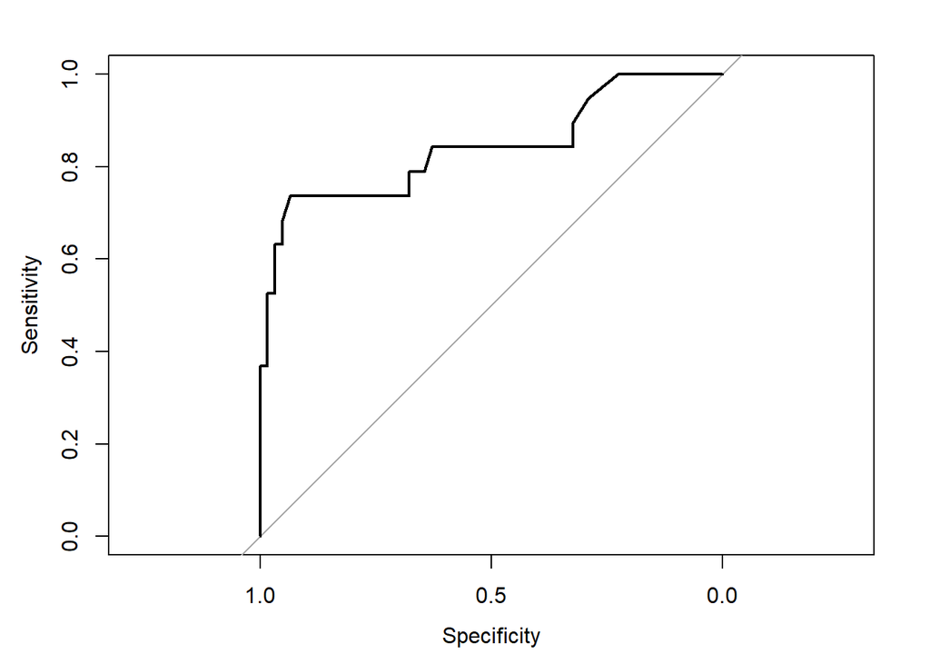

```r
test.data$forest.pred.prob <- predict(rf_classifier, test.data, type= "prob")
plot(roc(test.data$Attack, test.data$forest.pred.prob[,1]))
```

```r
auc(as.numeric(test.data$Attack), test.data$forest.pred.prob[,1])
```

```
## Area under the curve: 0.8413
```

The results indicate that the classifications are fairly accurate with no glaring issues. The model does predict the ‘no’ class a little too often, bu this is likely a result of the dataset more than anything else.

## **7.2 Logistic Regression**

Next we train a logistic regression model using the same predictors and examine the fit.

```r
glm.fit <- glm(Attack ~ Wd.Direction + moonphase + DailyAverageWdSpeed, data = train.data, family = binomial)
summary(glm.fit)
```

```
##
## Call:
## glm(formula = Attack ~ Wd.Direction + moonphase + DailyAverageWdSpeed,
##     family = binomial, data = train.data)
##
## Deviance Residuals:
##      Min        1Q    Median        3Q       Max
## -1.89223  -0.56913  -0.27126  -0.00006   2.89212
##
## Coefficients:
##                            Estimate Std. Error z value Pr(>|z|)
## (Intercept)                -0.81968    1.02708  -0.798   0.4248
## Wd.DirectionENE            -2.84257    1.52538  -1.864   0.0624 .
## Wd.DirectionESE            -2.20799    1.29063  -1.711   0.0871 .
## Wd.DirectionN             -20.47289 2302.31171  -0.009   0.9929
## Wd.DirectionNE             -2.95263    1.25908  -2.345   0.0190 *
## Wd.DirectionNNE            -2.52932    1.14000  -2.219   0.0265 *
## Wd.DirectionNNW           -18.24945 2064.73808  -0.009   0.9929
## Wd.DirectionNW            -17.98088 3153.37242  -0.006   0.9955
## Wd.DirectionS              -1.61315    1.08853  -1.482   0.1384
## Wd.DirectionSE             -0.75662    1.16457  -0.650   0.5159
## Wd.DirectionSSE            -0.61189    1.24625  -0.491   0.6234
## Wd.DirectionSSW            -0.57834    0.98292  -0.588   0.5563
## Wd.DirectionSW             -2.01105    0.95699  -2.101   0.0356 *
## Wd.DirectionW              -3.76015    1.55953  -2.411   0.0159 *
## Wd.DirectionWNW           -18.09178 3130.98585  -0.006   0.9954
## Wd.DirectionWSW            -2.39899    0.97085  -2.471   0.0135 *
## moonphaseFull               0.11238    0.65562   0.171   0.8639
## moonphaseLast quarter      -1.17770    1.18024  -0.998   0.3184
## moonphaseNew                0.17544    0.60800   0.289   0.7729
## moonphaseThird quarter     18.09643 4597.20628   0.004   0.9969
## moonphaseWaning crescent   -1.93071    1.30374  -1.481   0.1386
## moonphaseWaning gibbous    -0.22555    0.76607  -0.294   0.7684
## moonphaseWaxing crescent   -0.13820    0.81074  -0.170   0.8647
## moonphaseWaxing gibbous    -1.76452    0.99610  -1.771   0.0765 .
## DailyAverageWdSpeed         0.32753    0.05995   5.464 4.67e-08 ***
## ---
## Signif. codes:  0 '***' 0.001 '**' 0.01 '*' 0.05 '.' 0.1 ' ' 1
##
## (Dispersion parameter for binomial family taken to be 1)
##
##     Null deviance: 268.71  on 245  degrees of freedom
## Residual deviance: 170.06  on 221  degrees of freedom
## AIC: 220.06
##
## Number of Fisher Scoring iterations: 17
```

We then classify new data and examine the same three metrics: confustion matrix, gain curve plot, ROC plot, and AUC.

```r
test.data$logistic.pred <- predict(glm.fit, newdata = test.data, type = "response")
test.data$logistic.pred <- ifelse(test.data$logistic.pred >= 0.5, "Yes", "No")
test.data$logistic.pred <- factor(test.data$logistic.pred)
confusionMatrix(test.data$Attack, test.data$logistic.pred, positive = "Yes")
```

```
## Confusion Matrix and Statistics
##
##           Reference
## Prediction No Yes
##        No  56   6
##        Yes  6  13
##
##                Accuracy : 0.8519
##                  95% CI : (0.7555, 0.921)
##     No Information Rate : 0.7654
##     P-Value [Acc > NIR] : 0.03923
##
##                   Kappa : 0.5874
##  Mcnemar's Test P-Value : 1.00000
##
##             Sensitivity : 0.6842
##             Specificity : 0.9032
##          Pos Pred Value : 0.6842
##          Neg Pred Value : 0.9032
##              Prevalence : 0.2346
##          Detection Rate : 0.1605
##    Detection Prevalence : 0.2346
##       Balanced Accuracy : 0.7937
##
##        'Positive' Class : Yes
##
```

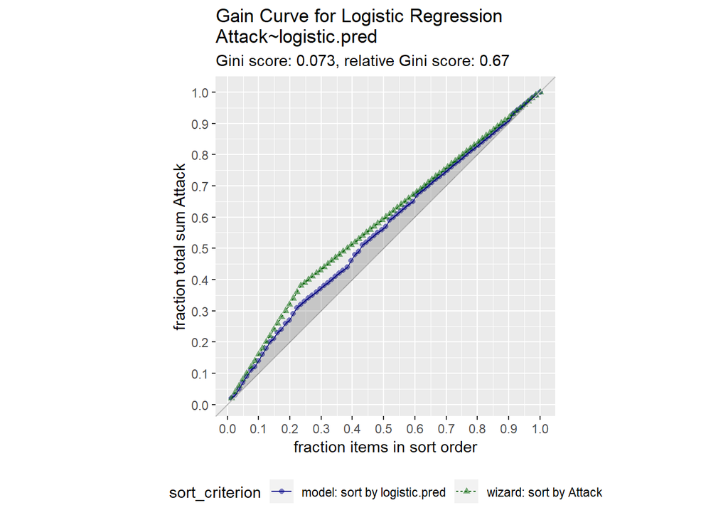

```r
GainCurvePlot(test.data, "logistic.pred", "Attack", "Gain Curve for Logistic Regression")
```

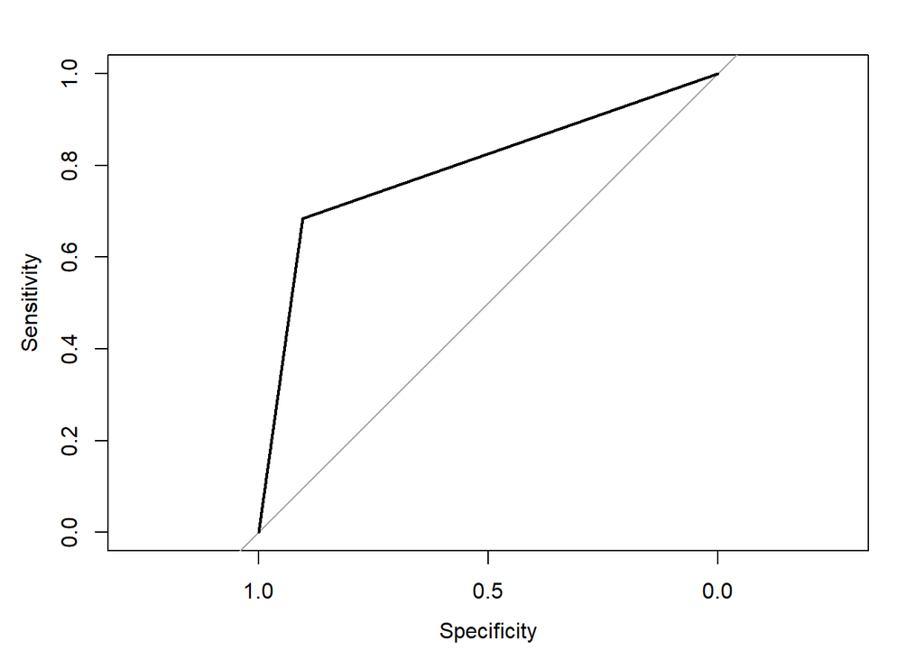

```r
plot(roc(test.data$Attack, as.numeric(test.data$logistic.pred)))
```

```r
auc(test.data$Attack, as.numeric(test.data$logistic.pred))
```

```
## Area under the curve: 0.7937
```

The performance is fairly similar to the random forest with good performance with a slight bias toward ‘no’ predictions.

## **7.3 Association Rules**

The association rules on moonphase, binned wind speed, and wind direction are applied using rattle.We chose these values based on domain knowledge as well as the fact that our data is taken from the summer months so temperature and precipitation do no vary enough to contribute to the association rules. The modeling method was employed using the apriori algorithm in order to find the best rules for consequent Attack = Yes.

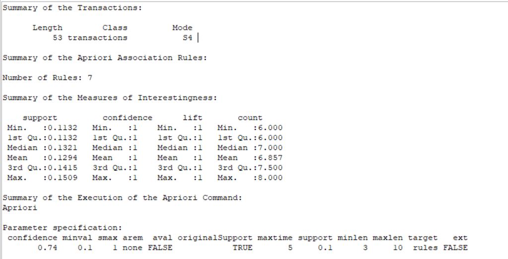

**Rules Obtained with 100% confidence**

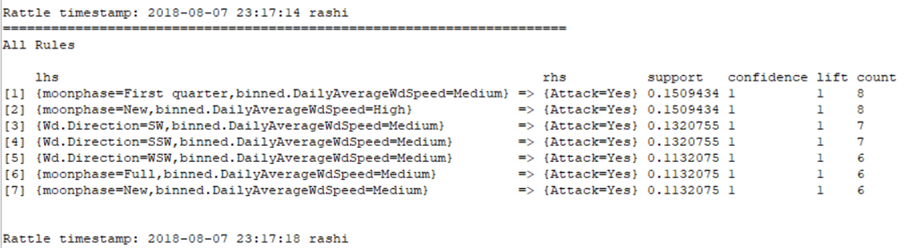

# **8. Model Evaluation Summary**

As we can see from the below statistics, Random Forest best fits the Shark data.

Summary

|  | Area Under Curve | Specificity | Sensitivity |
| --- | --- | --- | --- |
| Random Forest | 0.8413 | 0.9206 | 0.7778 |
| Logistic Regression | 0.7937 | 0.9032 | 0.6842 |

# **9. Conclusion and Deployment Recomendations**

Based on the good performance of these classifiers, the models could easily be combined with a stream of realtime weather data to accurately predict when shark attacks may occur. The biggest caveat to this is that the current data only contains information on actual shark attacks, it does not indicate any times when there may have been sharks near the shore, but there were no people in the water or the shark was spotted so people left the water. Expanding the dataset to include this information would dramatically increase the predictive ability of our models as it would provide the target variable we are really trying to predict, the presence of sharks, not just a symptom of it with their attacks.

Additional research could also be conducted in the area of data balancing. As mentioned in the beginning of the data modeling section, random undersampling caused a large variance in model results. If it is impossible to find additional data to better balance the classes then investigating alternate means of balancing data could potentially provide even more accurate results.